# CRIC Real data

- Show All Code
- Hide All Code
- View Source

Author

Affiliation

Ruxin Shi

Michigan State University, Statistics and Probability

Published

2024-02-11 14:50:53 EST

Modified

2024-02-11 14:50:34 EST

# 1 Purpose

This file provides results of MR-SPLIT being applied on the dataset CRIC

# 2 Setting

## 2.1 Define Global Options

Global R chunk options are defined in the YAML header but local chunk options will over-ride global options. We can temporarily disable an individual chunk by inserting `#| eval = FALSE` on a line at the top of the chunk. The method for creating a `cfsize` option that controls font size in code chunks and their text output is based on an answer to a question posted on [stackoverflow.com](https://stackoverflow.com/a/46526740).

````markdown
```{r}
#| label: global-options
#| cfsize: footnotesize

# Create a custom chunk hook/option for controlling font size in chunk & output.
# Global value for this is set in YAML header.
def.chunk.hook  <- knitr::knit_hooks$get("chunk")
knitr::knit_hooks$set(chunk = function(x, options) {
  x <- def.chunk.hook(x, options)
  ifelse(options$cfsize != "normalsize",
         paste0("\n \\", options$cfsize,"\n\n", x, "\n\n \\normalsize"),
         x)
  })
```
````

## 2.2 Load Packages

Load R packages that we need to get additional functions.

````markdown
```{r}
#| label: load-packages

library(ivreg)
library(MASS)
library(ggplot2)
library(hdi)
```
```{r}
#| label: load-packages

library(glmnet)
```
```{r}
#| label: load-packages

library(dplyr)
```
```{r}
#| label: load-packages

library(qqman)
```
````

```
For example usage please run: vignette('qqman')
```

```
Citation appreciated but not required:
```

```
Turner, (2018). qqman: an R package for visualizing GWAS results using Q-Q and manhattan plots. Journal of Open Source Software, 3(25), 731, https://doi.org/10.21105/joss.00731.
```

````markdown
```{r}
#| label: load-packages

library(screening)
library(foreach)
library(doParallel)
```
```{r}
#| label: load-packages

library(kableExtra)
```
```{r}
#| label: load-packages

library(quarto)           # for quarto_version()
library(gridExtra)
```
```{r}
#| label: load-packages

library(genetics)
```
````

[output not shown]

[output not shown]

[output not shown]

[output not shown]

[output not shown]

[output not shown]

[output not shown]

````markdown
```{r}
#| label: load-packages

library(SNPRelate)
```
````

```
SNPRelate -- supported by Streaming SIMD Extensions 2 (SSE2)
```

# 3 Application Results

## 3.1 Exposure: EGFR, Outcome: ATRH

### 3.1.1 GENE DATA: gene selected to have partial pvalue<0.01 with the exposure

````markdown
```{r eval=FALSE}
gene=read.table("../../msu/research/CRIC/derived data/onlywhite_gene_p01.txt",header = TRUE)
ncol(gene)
nrow(gene)
#NA
I=length(gene[1,])
for(j in 1:I){
    gene[,j]=as.factor(gene[,j])
    a=length(gene[is.na(gene[,j]),j])
    if(a!=0){
      if(is.factor(gene[1,j])==TRUE){
        k=summary(gene[,j])
        q=as.factor(names(k)[1:(length(k)-1)])
        gene[is.na(gene[,j]),j]=sample(q,a,replace = TRUE,prob=k[1:(length(k)-1)]/sum(k[1:(length(k)-1)]))
      }
    }
    gene[,j]=as.numeric(as.character(gene[,j]))
}

A=cor(gene)
need=NULL
for(i in 1:ncol(gene)){
  if(sum(abs(A[,i])>0.8)>=2)need=c(need,i)
}
gene_need_LD=gene[,need]
gene_LD=gene_need_LD
i=1
while(i<ncol(gene_LD)){
      snps_to_remove=apply(as.matrix(gene_LD[,(i+1):ncol(gene_LD)]),2,function(x)filter_ld(x,gene_LD[,i]))
      if((i+1)==ncol(gene_LD)){
        if(snps_to_remove==1)gene_LD=gene_LD[,1:i]
      }
      if((i+1)<ncol(gene_LD)){
        gene_LD_new=gene_LD[,(i+1):ncol(gene_LD)][,!snps_to_remove]
        gene_LD=cbind(gene_LD[,1:i], gene_LD_new)
      }
      i=i+1
      print(c("i"=i,ncol(gene_LD)))
}
Equal=makeequal(colnames(gene_need_LD),colnames(gene_LD))
gene=gene[,-need[-Equal[[1]]]]
write.table(gene,"../../msu/research/CRIC/derived data/onlywhite_gene_p01_LD.txt")
```
````

````markdown
```{r}
gene=read.table("../../msu/research/CRIC/derived data/onlywhite_gene_p01_LD.txt",header = TRUE)
ncol(gene)
nrow(gene)
```
````

```
[1] 4580
[1] 1353
```

### 3.1.2 Exposure: EGFR and Outcome: ATRH

````markdown
```{r}
makeequal <- function(A, B) {
  a=NULL
  b=NULL
  i <- 1
  q=1
  while (i <= length(A)) {
    B_id=grep(A[i],B)
    if (length(B_id)>0) {
      a[q]=i
      b[q]=B_id
      q=q+1
    }
    i=i+1
  }
  return(list(a,b))
}
filter_ld <- function(data1,data2) {
  ld_result <- LD(as.genotype.allele.count(data1), as.genotype.allele.count(data2))
  if (ld_result$`R^2` > r2_threshold) {
    return(1)
  }
  if (ld_result$`R^2` <= r2_threshold) {
    return(0)
  }
}
```
````

Summary of ATRH

|  | Number |
| --- | --- |
| 0 | 931 |
| 1 | 422 |

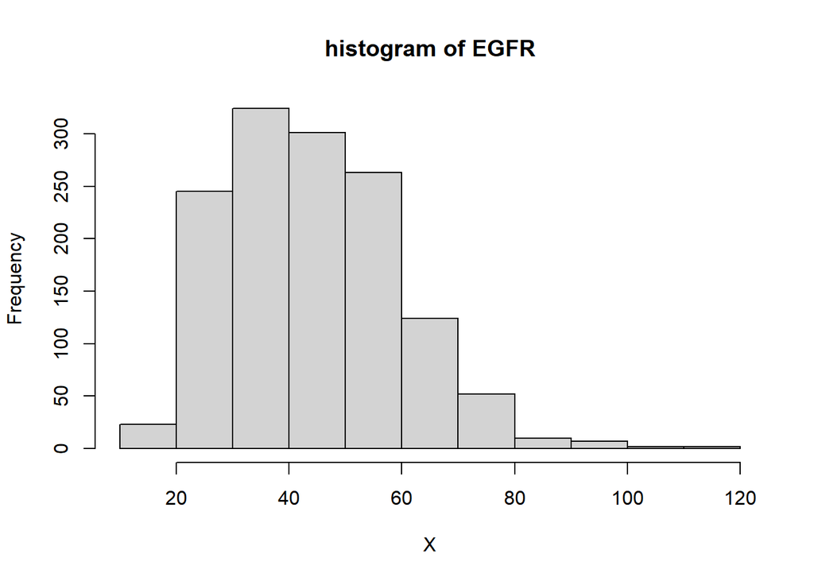

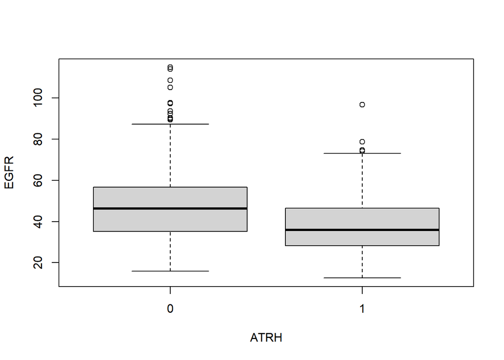

````markdown
```{r}
wd="C:/Users/shirx/OneDrive/Desktop/Major/Application on real data"
setwd(wd)
cova=read.table("../../msu/research/CRIC/derived data/white_covariates.txt",header = TRUE)
Data=read.table("../../msu/research/CRIC/derived data/all data(dummy).txt",header = TRUE)
whiteID=read.table("../../msu/research/CRIC/derived data/whiteID.txt")
onlywhite=makeequal(as.character(Data[,1]),as.character(whiteID))
Data=Data[onlywhite[[1]],]
EGFR=read.table("../../proposal/gene expression/graph_data_from_visit_level.txt",header = TRUE)
onlywhite2=makeequal(as.character(EGFR$ID),as.character(Data$PID))
EGFR=EGFR[onlywhite2[[1]],]

X=EGFR$EGFR_CRIC#EGFR,continuous
Y=Data[,2]#ATRH,binary
hist(X,main = "histogram of EGFR")
A=summary(as.factor(Y))
kable(A, "html", col.names = c("Number"),caption = "Summary of ATRH") %>%
  kable_styling()
boxplot(X~Y,xlab = "ATRH",ylab = "EGFR")
```
````

### 3.1.3 MR-SPLIT

Split times: 50

````markdown
```{r eval=FALSE}
N=length(X)
split.time=50
set.seed(100)
kk=2
weightcal=function(weight){
  len=length(weight)
  a=(weight>=0)
  b=abs(weight)/sum(abs(weight))
  c=NULL
  for(i in 1:len){
    if(a[i])c[i]=b[i]
    if(!a[i])c[i]=-1*b[i]
  }
  return(c)
}
point.est1=matrix(0,nrow=split.time,ncol=4)
colnames(point.est1)=c("Estimate","Std.error","t value","P.value")
num.major=NULL
num.weak=NULL
set.seed(2)
for(j in 1:split.time){
  #split sample
  selected=list()
  unselected=1:N
  n=sample(unselected,size=N/kk,replace = FALSE)
  selected[[1]]=n
  selected[[2]]=unselected[-n]

  selectIV=list()
  for(p in 1:kk){
    n=selected[[p]]
    fit=screening(gene[-n,],X[-n],method = "sis")
    selectIV[[p]]=gene[,fit$screen]
  }

  #LASSO
  weights=list()
  for(p in 1:kk){
    n=selected[[p]]
    #select IVs
    lambda=cv.glmnet(as.matrix(selectIV[[p]][-n,]),X[-n],alpha=1)$lambda.min
    lasso=glmnet(selectIV[[p]][-n,],X[-n],lambda=lambda)
    #coef of all IVs
    a=coef(lasso)[-1,]
    weights[[p]]=a[a!=0]
    #selected IVs
    selectIV[[p]]=selectIV[[p]][,a!=0]
  }
  length(selectIV[[1]][1,])
  #211
  length(selectIV[[2]][1,])
  #254

        #select major and weak based on partial F statistics
            partialF=list()
            for(p in 1:kk){
              n=selected[[p]]
              full=lm(X[-n]~.,data=selectIV[[p]][-n,])
              Fs=NULL
              if(length(selectIV[[p]])==1){
                Fs=summary(full)$fstat[1]
              }
              if(length(selectIV[[p]])>1){
                for(q in 1:length(selectIV[[p]])){
                  reduced=lm(X[-n]~.,data=selectIV[[p]][-n,-q])
                  Fs[q]=anova(reduced,full)$F[2]
                }
              }
              partialF[[p]]=Fs
            }
            selectmajor=list()
            selectweak=list()
            for(p in 1:kk){
              selectmajor[[p]]=as.matrix(selectIV[[p]][,partialF[[p]]>=30])
              selectweak[[p]]=as.matrix(selectIV[[p]][,partialF[[p]]<30])
              num.major=c(num.major,length(selectmajor[[p]][1,]))
              num.weak=c(num.weak,length(selectweak[[p]][1,]))
            }

   #Get combineMajor
  combineMajor=list()
  for(p in 1:kk){
    n=selected[[p]]
    weakwei=weights[[p]][partialF[[p]]<30]
    weakwei=weightcal(weakwei)
    combineMajor[[p]]=cbind(selectmajor[[p]][n,],as.matrix(selectweak[[p]][n,])%*%weakwei)
  }
  #MAJOR
  hatX=NULL
  for(p in 1:kk){
    n=selected[[p]]
    fit=lm(X[n]~.,data=as.data.frame(combineMajor[[p]]))
    hatX=c(hatX,fit$fitted.values)
  }
  ord=c(selected[[1]],selected[[2]])
  fit1 <- glm(Y[ord]~hatX, family = binomial(link = "logit"))
  point.est1[j,]=summary(fit1)$coef[2,1:4]

}
write.table(point.est1,"results/egfr_atrh_raw.txt",row.names = FALSE)
write.table(cbind(num.major,num.weak),"results/egfr_atrh_num_IVs_raw.txt",row.names = FALSE)
```
````

```
[1] 3.516383e-05
[1] -0.0352163
```

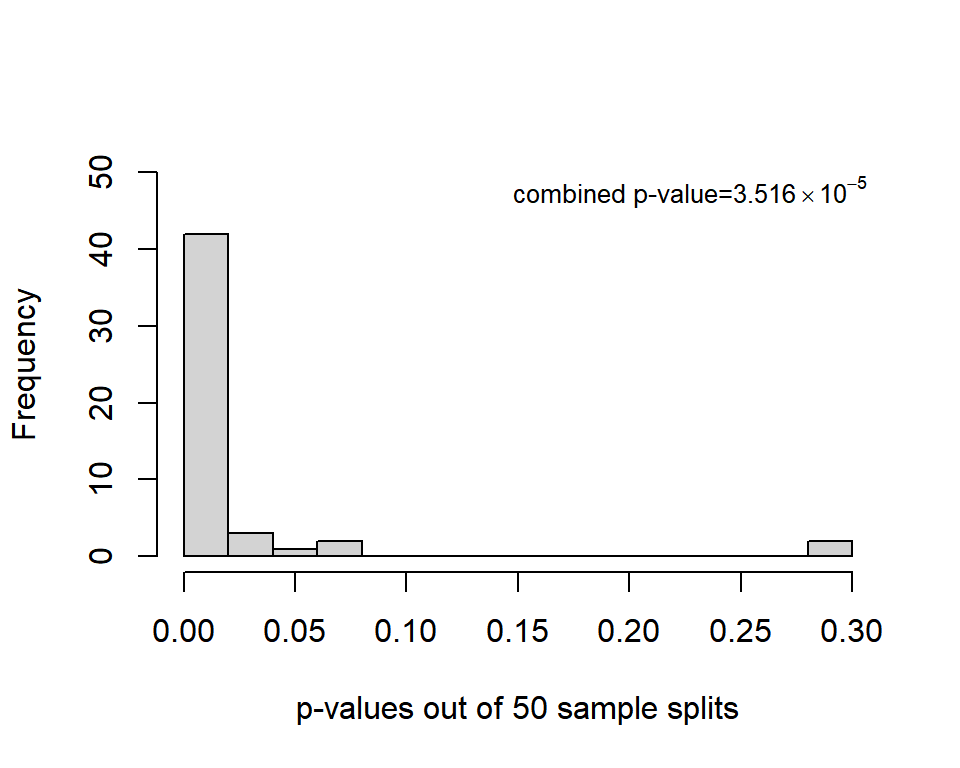

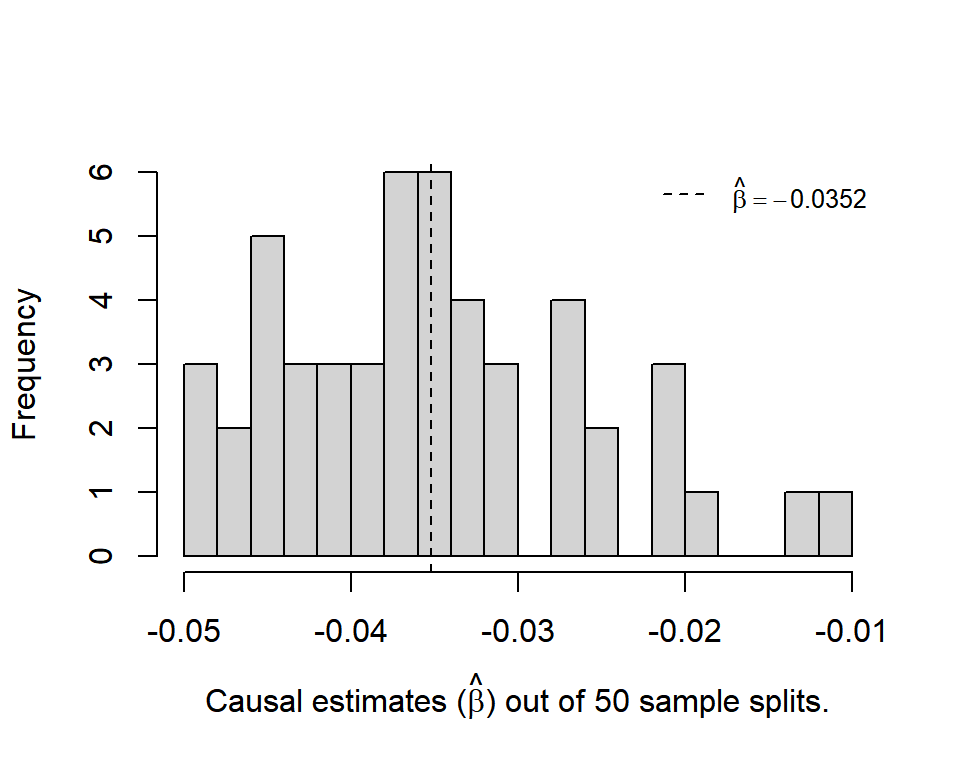

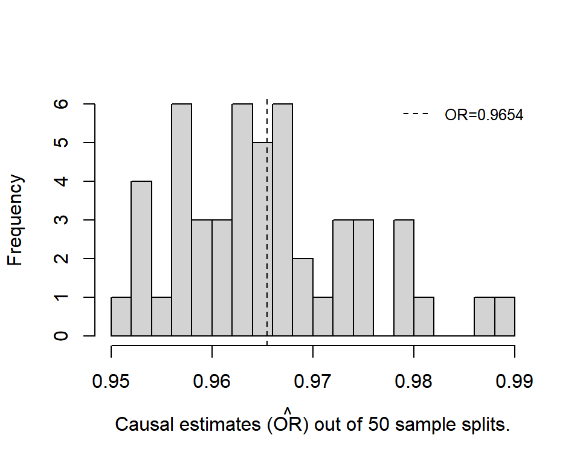

````markdown
```{r fig.height=4,fig.width=5}
MR_SPLIT=read.table("results/egfr_atrh_raw.txt",header = TRUE)
hist(MR_SPLIT[,4],main=NULL,breaks = 20,ylim=c(0,50),xlab = "p-values out of 50 sample splits")
#abline(v = 0.05, col = "black", lty = 2)
legend("topright", legend = expression("combined p-value=" * 3.516 %*% 10^-5), col = "black", cex = 0.8, bty = "n")


T1=mean(tan((0.5-MR_SPLIT[,4])*pi))
p1=0.5-atan(T1)/pi
print(p1)
hist(MR_SPLIT[,1], breaks = 20, main = NULL,
     xlab = expression("Causal estimates (" * hat(beta) * ") out of 50 sample splits."))

abline(v = mean(MR_SPLIT[,1]), col = "black", lty = 2)
legend("topright", legend = expression(hat(beta) == -0.0352), lty = 2, col = "black", cex = 0.8, bty = "n")

print(mean(MR_SPLIT[,1]))

hist(exp(MR_SPLIT[,1]), breaks = 20, main = NULL,
     xlab = expression("Causal estimates (" * hat(OR) * ") out of 50 sample splits."))

abline(v = mean(exp(MR_SPLIT[,1])), col = "black", lty = 2)
legend("topright", legend = "OR=0.9654", lty = 2, col = "black", cex = 0.8, bty = "n")
```
````

### 3.1.4 CFMR

````markdown
```{r eval=FALSE}
N=length(X)

set.seed(2)
k=10
#CFMR
{
  #split sample
  selected=NULL
  unselected=1:N
  n=sample(unselected,size=N/k,replace = FALSE)
  selected=cbind(selected,n)
  for(p in 1:k){
    if(p<k){
      n=sample(unselected[-selected],size=N/k,replace = FALSE)
      selected=cbind(selected,n)
    }
  }

  selectIV=list()
  for(p in 1:k){
    n=selected[[p]]
    fit=screening(gene[-n,],X[-n],method = "sis")
    selectIV[[p]]=gene[,fit$screen]
  }
  #LASSO
  combineCFMR=NULL
  for(p in 1:k){
    n=selected[,p]
    #select IVs
    lasso=cv.glmnet(as.matrix(selectIV[[p]][-n,]),X[-n],alpha=1)
    #coef of all IVs
    combineCFMR=c(combineCFMR,predict(lasso,as.matrix(selectIV[[p]][n,]), s = "lambda.min"))
  }

  ord=c(selected)
  #CFMR
   first1=lm(X[ord]~combineCFMR)
    fit1=glm(Y[ord]~first1$fitted.values,family = binomial(link = "logit"))
  CFMR=c(summary(fit1)$coef[2,c(1:4)])
}
write.table(CFMR,"results/CFMR_egfr_atrh_raw.txt",row.names = FALSE)
```
````

````markdown
```{r}
CFMR=read.table("results/CFMR_egfr_atrh_raw.txt",header = TRUE)
rownames(CFMR)=c("Estimate","Std. Error","t value","Pr(>|t|)")
kable(round(CFMR,4), "html", col.names = c("CFMR"),caption = "Results of CFMR") %>%
  kable_styling()
```
````

Results of CFMR

|  | CFMR |
| --- | --- |
| Estimate | -0.0378 |
| Std. Error | 0.0056 |
| t value | -6.7495 |
| Pr(>\|t\|) | 0.0000 |

### 3.1.5 2SLS

````markdown
```{r}
times=1
set.seed(100)
#TSLS
point.est1=matrix(NA,ncol=4,nrow=times)

#NA
I=length(gene[1,])
set.seed(2)
for(j in 1:I){
    gene[,j]=as.factor(gene[,j])
    a=length(gene[is.na(gene[,j]),j])
    if(a!=0){
      if(is.factor(gene[1,j])==TRUE){
        k=summary(gene[,j])
        q=as.factor(names(k)[1:(length(k)-1)])
        gene[is.na(gene[,j]),j]=sample(q,a,replace = TRUE,prob=k[1:(length(k)-1)]/sum(k[1:(length(k)-1)]))
      }
    }
    gene[,j]=as.numeric(as.character(gene[,j]))
}

for(t in 1:times){
  #TSLS
  #select IVs using SIS
  selectIV=NULL
  fit=screening(gene,X,method = "sis")
  selectIV=gene[,fit$screen]
  #LASSO
  #select IVs
  lambda=cv.glmnet(as.matrix(selectIV),X,alpha=1)$lambda.min
  lasso=glmnet(selectIV,X,lambda=lambda)
  #coef of all IVs
  a=coef(lasso)[-1,]
  #selected IVs
  selectIV=selectIV[,a!=0]
  first1=lm(X~as.matrix(selectIV))
  fit1=glm(Y~first1$fitted.values,family = binomial(link = "logit"))
  point.est1[t,]=summary(fit1)$coef[2,1:4]
}

colnames(point.est1)=c("Estimate","Std.error","t value","P.value")
kable(point.est1, "html", caption = "Summary of 2SLS") %>%
  kable_styling()
```
````

Summary of 2SLS

| Estimate | Std.error | t value | P.value |
| --- | --- | --- | --- |
| -0.040739 | 0.0048752 | -8.356346 | 0 |

### 3.1.6 Summary

````markdown
```{r}
A=matrix(0,nrow=3,ncol=2)
rownames(A)=c("MR-SPLIT","CFMR","2SLS")
colnames(A)=c("Estimates","Pvalue")
A[1,]=c(mean(MR_SPLIT[,1]),p1)
A[2,]=c(CFMR[1,1],CFMR[4,1])
A[3,]=point.est1[1,c(1,4)]
kable(A, "html", caption = "Comparison between methods") %>%
  kable_styling()
```
````

Comparison between methods

|  | Estimates | Pvalue |
| --- | --- | --- |
| MR-SPLIT | -0.0352163 | 3.52e-05 |
| CFMR | -0.0377625 | 0.00e+00 |
| 2SLS | -0.0407390 | 0.00e+00 |

## 3.2 Exposure: uACR, Outcome: ATRH

### 3.2.1 Exposure: uACR and Outcome: ATRH

````markdown
```{r}
makeequal <- function(A, B) {
  a=NULL
  b=NULL
  i <- 1
  q=1
  while (i <= length(A)) {
    B_id=grep(A[i],B)
    if (length(B_id)>0) {
      a[q]=i
      b[q]=B_id
      q=q+1
    }
    i=i+1
  }
  return(list(a,b))
}
r2_threshold=0.8
filter_ld <- function(data1,data2) {
  ld_result <- LD(as.genotype.allele.count(data1), as.genotype.allele.count(data2))
  if (ld_result$`R^2` > r2_threshold) {
    return(1)
  }
  if (ld_result$`R^2` <= r2_threshold) {
    return(0)
  }
}
```
````

````markdown
```{r eval=FALSE}
library(sas7bdat)
visit=read.sas7bdat("../../msu/research/CRIC/derived data/visitlevel.sas7bdat")
X1=cbind(visit$PID,visit$UALBUMIN24H)
X2=cbind(visit$PID,visit$UCREATININE24H)
base=read.csv("derived data/baseline.csv")
Y=base[,c(2,27)]#others are all included in v3

Data=cbind(X1,X2[,2])
Data=Data[Data[,2]!="NaN",]
Data=Data[Data[,3]!="NaN",]
colnames(Data)=c("PID","ALBUMIN","CREATININE")

whiteID=read.table("derived data/whiteID.txt")
onlywhite=makeequal(as.character(as.numeric(Data[,1])),as.character(whiteID[,1]))
Data=Data[onlywhite[[1]],]
onlywhite=makeequal(as.character(Y[,1]),as.character((Data[,1])))
Y=Y[onlywhite[[1]],]

write.table(cbind(Data,Y[,2]),"../../msu/research/CRIC/derived data/uACR and ATRH_white.txt",row.names = FALSE)
```
````

Summary of ATRH

|  | Number |
| --- | --- |
| 0 | 912 |
| 1 | 412 |

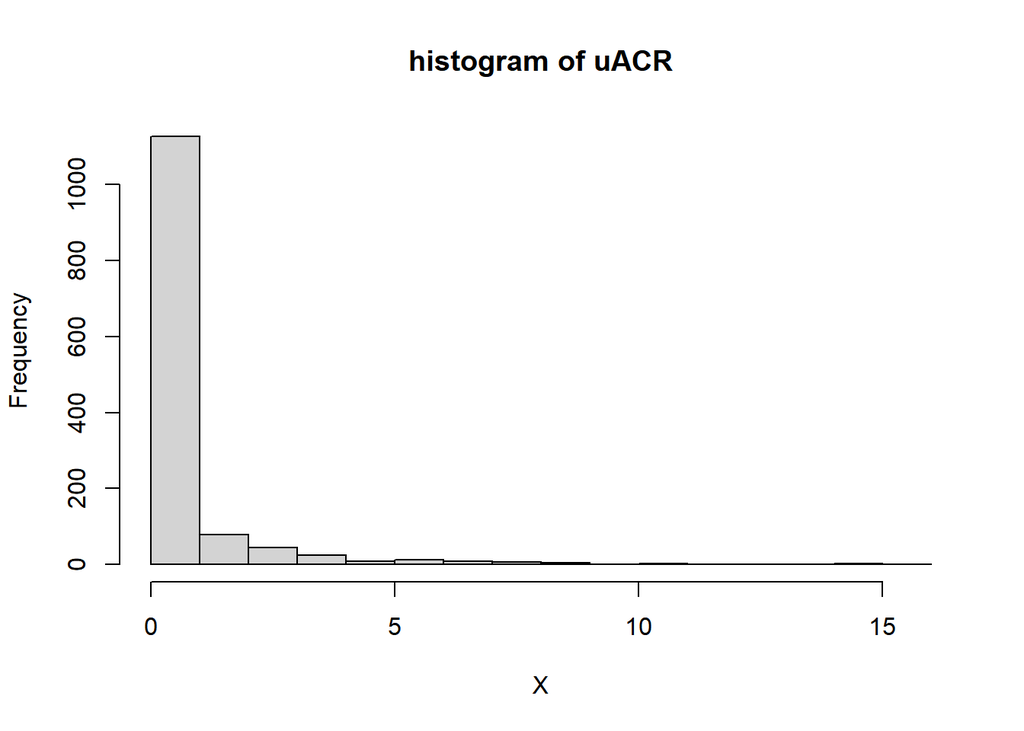

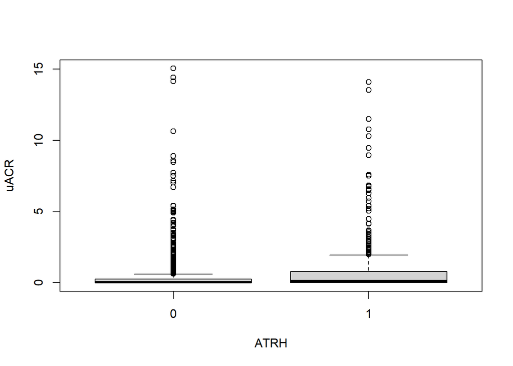

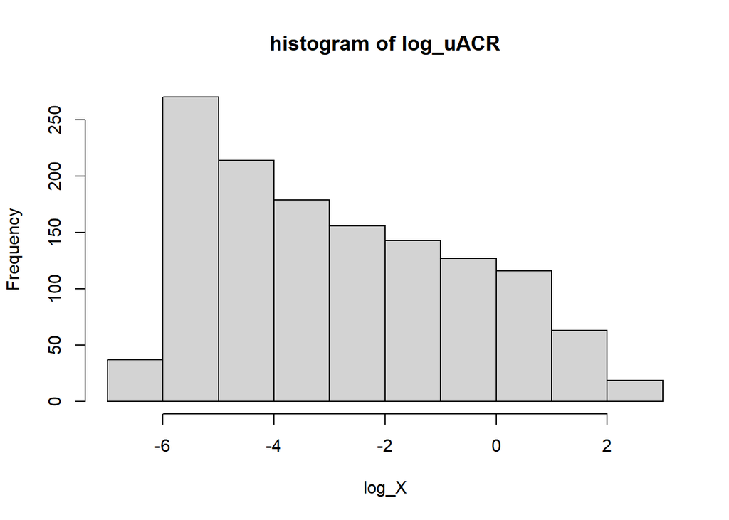

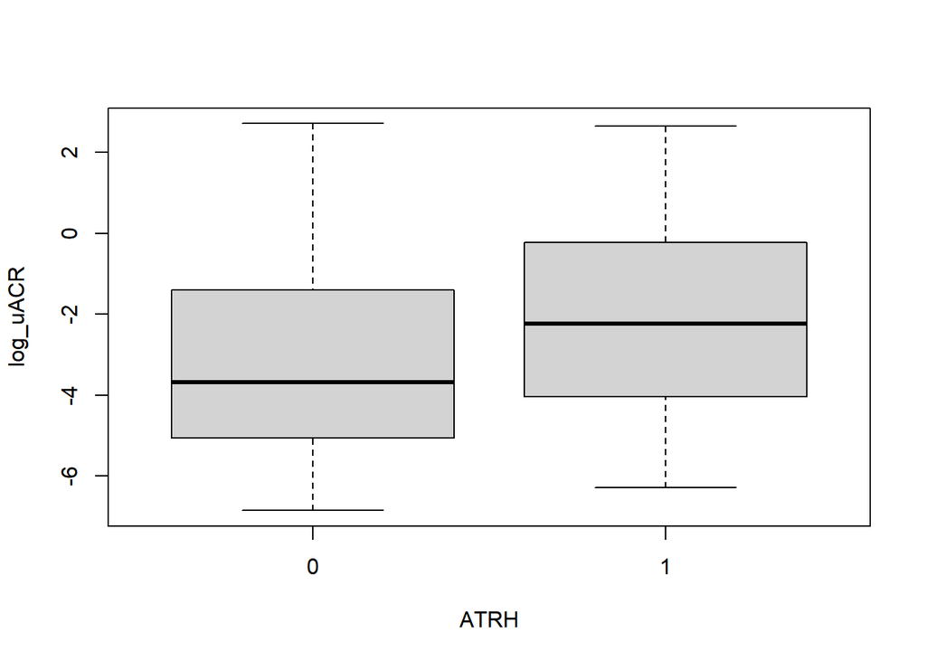

````markdown
```{r}
Data=read.table("../../msu/research/CRIC/derived data/uACR and ATRH_white.txt",header = TRUE)
X=Data[,2]/Data[,3]#uACR
Y=Data[,4]#ATRH
hist(X,main = "histogram of uACR")
boxplot(X~Y,xlab = "ATRH",ylab = "uACR")

log_X=log(X)
hist(log_X,main = "histogram of log_uACR")
A=summary(as.factor(Y))
kable(A, "html", col.names = c("Number"),caption = "Summary of ATRH") %>%
  kable_styling()
boxplot(log_X~Y,xlab = "ATRH",ylab = "log_uACR")
```
````

So I use log(uACR) as the exposure.

### 3.2.2 GENE DATA: gene selected to have partial pvalue<0.01 with the exposure

````markdown
```{r eval=FALSE}
library(trio)
library(foreach)
library(doParallel)
num <- c(1:24)
gene_select2=NA
cl <- makeCluster(14)
registerDoParallel(cl)
for(i in num){
  path <- paste0("derived data/chr",i, ".raw")
  gene <- read.pedfile(file = path)[,-c(2:6)]
  gene=gene[-1,]
  onlywhite=makeequal(as.character(gene[,1]),as.character(Data$PID))
  gene=gene[onlywhite[[1]],]
  gene=gene[,-1]

  I=length(gene[1,])
  pvalue=NULL

  results=foreach(j=1:I, .combine=rbind)%dopar%{
    #NA
    gene[,j]=as.factor(gene[,j])
    a=length(gene[is.na(gene[,j]),j])
    if(a!=0){
      if(is.factor(gene[1,j])==TRUE){
        k=summary(gene[,j])
        q=as.factor(names(k)[1:(length(k)-1)])
        gene[is.na(gene[,j]),j]=sample(q,a,replace = TRUE,prob=k[1:(length(k)-1)]/sum(k[1:(length(k)-1)]))
      }
    }
    #pvalue
    gene[,j]=as.numeric(as.character(gene[,j]))
    fit=lm(X~gene[,j])
    pvalue=summary(fit)$coef[2,4]
    return(pvalue)
  }

  colnames(gene)=paste(i,colnames(gene),seq="")
  gene_select2=cbind(gene_select2,gene[,results<=0.01])
  #gene_select3=cbind(gene_select3,gene[,pvalue<=0.001])
}
stopCluster(cl)
#p
write.table(gene_select2[,-1],"derived data/onlywhite_gene_p01_uACR.txt",row.names = FALSE)
```
````

````markdown
```{r eval=FALSE}
gene=read.table("../../msu/research/CRIC/derived data/onlywhite_gene_p01_uACR.txt",header = TRUE)
ncol(gene)
nrow(gene)
#NA
I=length(gene[1,])
for(j in 1:I){
    gene[,j]=as.factor(gene[,j])
    a=length(gene[is.na(gene[,j]),j])
    if(a!=0){
      if(is.factor(gene[1,j])==TRUE){
        k=summary(gene[,j])
        q=as.factor(names(k)[1:(length(k)-1)])
        gene[is.na(gene[,j]),j]=sample(q,a,replace = TRUE,prob=k[1:(length(k)-1)]/sum(k[1:(length(k)-1)]))
      }
    }
    gene[,j]=as.numeric(as.character(gene[,j]))
}

A=cor(gene)
need=NULL
for(i in 1:ncol(gene)){
  if(sum(abs(A[,i])>0.8)>=2)need=c(need,i)
}
gene_need_LD=gene[,need]
gene_LD=gene_need_LD
i=1
while(i<ncol(gene_LD)){
      snps_to_remove=apply(as.matrix(gene_LD[,(i+1):ncol(gene_LD)]),2,function(x)filter_ld(x,gene_LD[,i]))
      if((i+1)==ncol(gene_LD)){
        if(snps_to_remove==1)gene_LD=gene_LD[,1:i]
      }
      if((i+1)<ncol(gene_LD)){
        gene_LD_new=gene_LD[,(i+1):ncol(gene_LD)][,!snps_to_remove]
        gene_LD=cbind(gene_LD[,1:i], gene_LD_new)
      }
      i=i+1
      print(c("i"=i,ncol(gene_LD)))
}
Equal=makeequal(colnames(gene_need_LD),colnames(gene_LD))
gene=gene[,-need[-Equal[[1]]]]
write.table(gene,"../../msu/research/CRIC/derived data/onlywhite_gene_p01_uACR_LD.txt")
```
````

````markdown
```{r}
gene=read.table("../../msu/research/CRIC/derived data/onlywhite_gene_p01_uACR_LD.txt",header = TRUE)
ncol(gene)
nrow(gene)
```
````

```
[1] 4041
[1] 1324
```

### 3.2.3 MR-SPLIT

Split times: 50

````markdown
```{r eval=FALSE}
X=log_X
N=length(X)
split.time=50
set.seed(100)
kk=2
weightcal=function(weight){
  len=length(weight)
  a=(weight>=0)
  b=abs(weight)/sum(abs(weight))
  c=NULL
  for(i in 1:len){
    if(a[i])c[i]=b[i]
    if(!a[i])c[i]=-1*b[i]
  }
  return(c)
}
point.est1=matrix(0,nrow=split.time,ncol=4)
colnames(point.est1)=c("Estimate","Std.error","t value","P.value")

set.seed(2)
num.major=NULL
num.weak=NULL
for(j in 1:split.time){
  #split sample
  selected=list()
  unselected=1:N
  n=sample(unselected,size=N/kk,replace = FALSE)
  selected[[1]]=n
  selected[[2]]=unselected[-n]

  selectIV=list()
  for(p in 1:kk){
    n=selected[[p]]
    fit=screening(gene[-n,],X[-n],method = "sis")
    selectIV[[p]]=gene[,fit$screen]
  }

  #LASSO
  weights=list()
  for(p in 1:kk){
    n=selected[[p]]
    #select IVs
    lambda=cv.glmnet(as.matrix(selectIV[[p]][-n,]),X[-n],alpha=1)$lambda.min
    lasso=glmnet(selectIV[[p]][-n,],X[-n],lambda=lambda)
    #coef of all IVs
    a=coef(lasso)[-1,]
    weights[[p]]=a[a!=0]
    #selected IVs
    selectIV[[p]]=selectIV[[p]][,a!=0]
  }

   #select major and weak based on partial F statistics
            partialF=list()
            for(p in 1:kk){
              n=selected[[p]]
              full=lm(X[-n]~.,data=selectIV[[p]][-n,])
              Fs=NULL
              if(length(selectIV[[p]])==1){
                Fs=summary(full)$fstat[1]
              }
              if(length(selectIV[[p]])>1){
                for(q in 1:length(selectIV[[p]])){ reduced=lm(X[-n]~.,data=selectIV[[p]][-n,-q])
                  Fs[q]=anova(reduced,full)$F[2]
                }
              }
              partialF[[p]]=Fs
            }
            selectmajor=list()
            selectweak=list()
            for(p in 1:kk){
              selectmajor[[p]]=as.matrix(selectIV[[p]][,partialF[[p]]>=30])
              selectweak[[p]]=as.matrix(selectIV[[p]][,partialF[[p]]<30])
              num.major=c(num.major,length(selectmajor[[p]][1,]))
              num.weak=c(num.weak,length(selectweak[[p]][1,]))
            }

   #Get combineMajor

  combineMajor=list()
  for(p in 1:kk){
    n=selected[[p]]
    weakwei=weights[[p]][partialF[[p]]<30]
    weakwei=weightcal(weakwei)
    combineMajor[[p]]=cbind(selectmajor[[p]][n,],as.matrix(selectweak[[p]][n,])%*%weakwei)
  }
  #MAJOR
  hatX=NULL
  for(p in 1:kk){
    n=selected[[p]]
    fit=lm(X[n]~.,data=as.data.frame(combineMajor[[p]]))
    hatX=c(hatX,fit$fitted.values)
  }
  ord=c(selected[[1]],selected[[2]])
  fit1 <- glm(Y[ord]~hatX, family = binomial(link = "logit"))
  point.est1[j,]=summary(fit1)$coef[2,1:4]

}
write.table(point.est1,"results/uACR_atrh.txt",row.names = FALSE)
write.table(cbind(num.major,num.weak),"results/uACR_atrh_num_IV.txt",row.names = FALSE)
```
````

```
[1] 0.0002593469
[1] 0.1826666
```

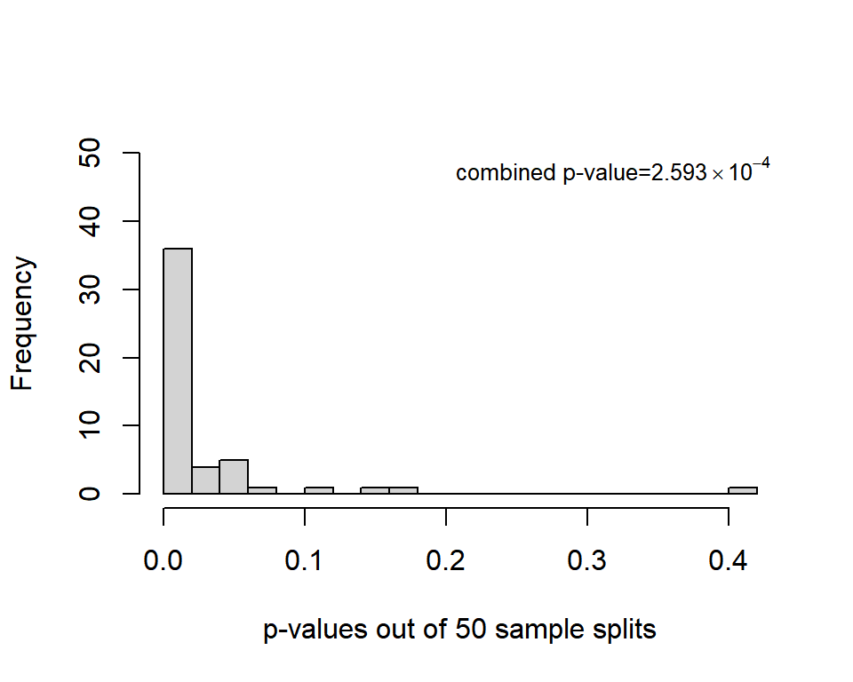

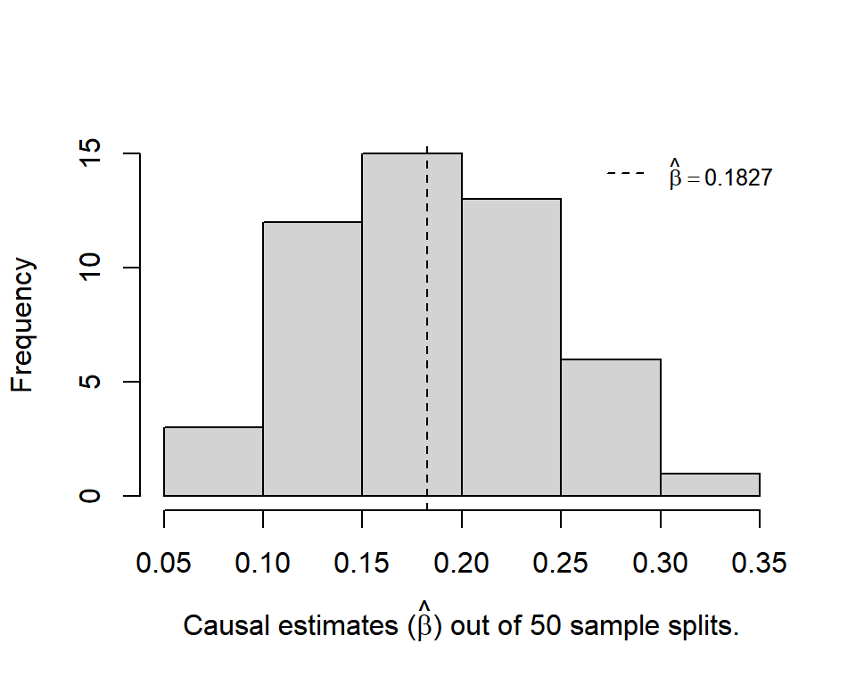

````markdown
```{r fig.height=4,fig.width=5}
MR_SPLIT=read.table("results/uACR_atrh.txt",header = TRUE)
hist(MR_SPLIT[,4],xlab = "p-values out of 50 sample splits",breaks = 20,ylim=c(0,50),main=NULL)
#abline(v = 0.05, col = "black", lty = 2)
legend("topright", legend = expression("combined p-value=" * 2.593 %*% 10^-4),  col = "black", cex = 0.8, bty = "n")

T1=mean(tan((0.5-MR_SPLIT[,4])*pi))
p1=0.5-atan(T1)/pi
print(p1)
hist(MR_SPLIT[,1], breaks = 8,  xlab = expression("Causal estimates (" * hat(beta) * ") out of 50 sample splits."), main = NULL)
abline(v = mean(MR_SPLIT[,1]), col = "black", lty = 2)
legend("topright", legend = expression(hat(beta) == 0.1827), lty = 2, col = "black", cex = 0.8, bty = "n")
print(mean(MR_SPLIT[,1]))
```
````

### 3.2.4 CFMR

````markdown
```{r eval=FALSE}
X=log_X
N=length(X)
weightcal=function(weight){
  len=length(weight)
  a=(weight>=0)
  b=abs(weight)/sum(abs(weight))
  c=NULL
  for(i in 1:len){
    if(a[i])c[i]=b[i]
    if(!a[i])c[i]=-1*b[i]
  }
  return(c)
}

set.seed(2)
#CFMR
{
  #split sample
  selected=NULL
  unselected=1:N
  n=sample(unselected,size=N/k,replace = FALSE)
  selected=cbind(selected,n)
  for(p in 1:k){
    if(p<k){
      n=sample(unselected[-selected],size=N/k,replace = FALSE)
      selected=cbind(selected,n)
    }
  }
   selectIV=list()
  for(p in 1:k){
    n=selected[[p]]
    fit=screening(gene[-n,],X[-n],method = "sis")
    selectIV[[p]]=gene[,fit$screen]
  }
  #LASSO
  combineCFMR=NULL
  for(p in 1:k){
    n=selected[,p]
    #select IVs
    lasso=cv.glmnet(as.matrix(selectIV[[p]][-n,]),X[-n],alpha=1)
    #coef of all IVs
    combineCFMR=c(combineCFMR,predict(lasso,as.matrix(selectIV[[p]][n,]), s = "lambda.min"))
  }

  ord=c(selected)
  #CFMR
   first1=lm(X[ord]~combineCFMR)
    fit1=glm(Y[ord]~first1$fitted.values,family = binomial(link = "logit"))
  CFMR=c(summary(fit1)$coef[2,c(1:4)])
}
write.table(CFMR,"results/CFMR_uACR.txt",row.names = FALSE)
```
````

````markdown
```{r}
CFMR=read.table("results/CFMR_uACR.txt",header = TRUE)
rownames(CFMR)=c("Estimate","Std. Error","t value","Pr(>|t|)")
kable(round(CFMR,4), "html", col.names = c("CFMR"),caption = "Results of CFMR") %>%
  kable_styling()
```
````

Results of CFMR

|  | CFMR |
| --- | --- |
| Estimate | 0.1584 |
| Std. Error | 0.0391 |
| t value | 4.0460 |
| Pr(>\|t\|) | 0.0001 |

````markdown
```{r}
times=1
set.seed(100)
#TSLS
point.est1=matrix(NA,ncol=4,nrow=times)

for(t in 1:times){
  #TSLS and LIML
  #select IVs using SIS
  selectIV=NULL
  fit=screening(gene,X,method = "sis")
  selectIV=gene[,fit$screen]
  #LASSO
  #select IVs
  lambda=cv.glmnet(as.matrix(selectIV),X,alpha=1)$lambda.min
  lasso=glmnet(selectIV,X,lambda=lambda)
  #coef of all IVs
  a=coef(lasso)[-1,]
  #selected IVs
    first1=lm(X~as.matrix(selectIV))
  fit1=lm(Y~first1$fitted.values,family = binomial(link = "logit"))
  point.est1[t,]=summary(fit1)$coef[2,1:4]
  #fit1=ivmodel(Y=Y,D=X,Z=selectIV)

  #point.est2[t,]=c(fit1$LIML$point.est,fit1$LIML$std.err,fit1$LIML$test.stat.other,fit1$LIML$p.value)
}

colnames(point.est1)=c("Estimate","Std.error","t value","P.value")
#colnames(point.est2)=c("Estimate","Std.error","t value","P.value")
kable(point.est1, "html", caption = "Summary of 2SLS") %>%
  kable_styling()
#kable(point.est2, "html", caption = "Summary of LIML") %>%
#  kable_styling()
```
````

Summary of 2SLS

| Estimate | Std.error | t value | P.value |
| --- | --- | --- | --- |
| 0.0363691 | 0.0083069 | 4.378201 | 1.29e-05 |

### 3.2.6 Summary

````markdown
```{r}
#A=matrix(0,nrow=4,ncol=2)
#rownames(A)=c("MR-SPLIT","CFMR","2SLS","LIML")
A=matrix(0,nrow=3,ncol=2)
rownames(A)=c("MR-SPLIT","CFMR","2SLS")
colnames(A)=c("Estimates","Pvalue")
A[1,]=c(mean(MR_SPLIT[,1]),p1)
A[2,]=c(CFMR[1,1],CFMR[4,1])
A[3,]=point.est1[1,c(1,4)]
#A[4,]=point.est2[1,c(1,4)]
kable(A, "html", caption = "Comparison between methods") %>%
  kable_styling()
```
````

Comparison between methods

|  | Estimates | Pvalue |
| --- | --- | --- |
| MR-SPLIT | 0.1826666 | 0.0002593 |
| CFMR | 0.1583845 | 0.0000521 |
| 2SLS | 0.0363691 | 0.0000129 |

# 4 Software Information

This section documents information that is important for reproducibility. Most users will not need to read it. It is primarily here for use by the statistician on the team.

We used [R](https://www.r-project.org/) as our main computing environment and [Quarto](https://quarto.org/) scripts to enhance reproducibility. We used RStudio as the editor to interface with R and Quarto.

- Software chain: **qmd file > RStudio > Quarto > R > knitr > md file > Pandoc > html file**.
- Source file: **CRIC Real data.qmd**
- Output file: **CRIC Real data.html**
- [Quarto 1.4.544](https://quarto.org/) runs `*.qmd` files through [R](https://www.r-project.org/) and [knitr](https://yihui.org/knitr/) to produce `*.md` markdown files.
- [Pandoc 3.1.1](https://pandoc.org) converts markdown files (`*.md`) to other formats, including LaTeX (`*.tex`) and HTML (`*.html`) among others.

## 4.1 Versions